# Chapter 7: Moving Beyond Linearity

Paulo Loyola

Loads the libraries:

```r
library(ISLR)
library(boot)
library(splines)
library(gam)
library(MASS)
library(leaps)
```

**6)** **a)** K-fold cross-validation on Wage (polynomial fit):

```r
set.seed(1)
cv.error.10 = c()
for(i in 1:10) {glm.fit = glm(wage~poly(age, i), data=Wage)
cv.error.10[i] = cv.glm(Wage, glm.fit, K = 10)$delta[1]}
cv.error.10
```

```
##  [1] 1675.837 1601.012 1598.801 1594.217 1594.625 1594.888 1595.500
##  [8] 1595.436 1596.335 1595.835
```

ANOVA

```r
glm.fit1 = glm(wage~age, data=Wage)
glm.fit2 = glm(wage~poly(age, 2), data=Wage)
glm.fit3 = glm(wage~poly(age, 3), data=Wage)
glm.fit4 = glm(wage~poly(age, 4), data=Wage)
glm.fit5 = glm(wage~poly(age, 5), data=Wage)
glm.fit6 = glm(wage~poly(age, 6), data=Wage)
glm.fit7 = glm(wage~poly(age, 7), data=Wage)
glm.fit8 = glm(wage~poly(age, 8), data=Wage)
glm.fit9 = glm(wage~poly(age, 9), data=Wage)
glm.fit10 = glm(wage~poly(age, 10), data=Wage)
anova(glm.fit1, glm.fit2, glm.fit3, glm.fit4, glm.fit5, glm.fit6, glm.fit7, glm.fit8, glm.fit9, glm.fit10, test="F")
```

```
## Analysis of Deviance Table
##
## Model  1: wage ~ age
## Model  2: wage ~ poly(age, 2)
## Model  3: wage ~ poly(age, 3)
## Model  4: wage ~ poly(age, 4)
## Model  5: wage ~ poly(age, 5)
## Model  6: wage ~ poly(age, 6)
## Model  7: wage ~ poly(age, 7)
## Model  8: wage ~ poly(age, 8)
## Model  9: wage ~ poly(age, 9)
## Model 10: wage ~ poly(age, 10)
##    Resid. Df Resid. Dev Df Deviance        F    Pr(>F)
## 1       2998    5022216
## 2       2997    4793430  1   228786 143.7638 < 2.2e-16 ***
## 3       2996    4777674  1    15756   9.9005  0.001669 **
## 4       2995    4771604  1     6070   3.8143  0.050909 .
## 5       2994    4770322  1     1283   0.8059  0.369398
## 6       2993    4766389  1     3932   2.4709  0.116074
## 7       2992    4763834  1     2555   1.6057  0.205199
## 8       2991    4763707  1      127   0.0796  0.777865
## 9       2990    4756703  1     7004   4.4014  0.035994 *
## 10      2989    4756701  1        3   0.0017  0.967529
## ---
## Signif. codes:  0 '***' 0.001 '**' 0.01 '*' 0.05 '.' 0.1 ' ' 1
```

Plots the results:

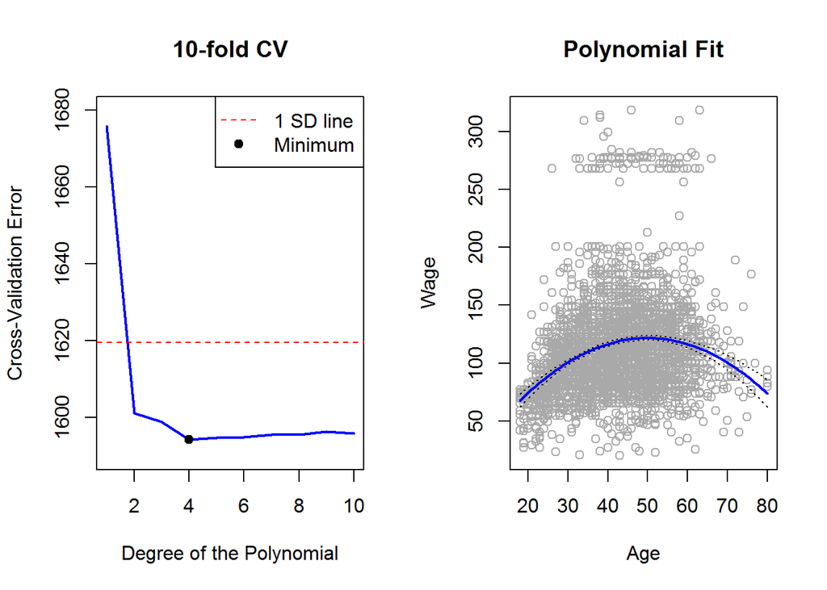

```r
par(mfrow=c(1,2))
minimum = min(cv.error.10)
sdKfold = sd(cv.error.10)

# Cross-Validation Plot
plot(1:10, cv.error.10, xlab="Degree of the Polynomial", ylab="Cross-Validation Error", type="l", pch=20, lwd=2, ylim=c(1590, 1680), col="blue", main = "10-fold CV")
abline(h = minimum + sdKfold, col="red", lty="dashed")
points(x = which.min(cv.error.10), y = minimum, pch=19)
legend("topright", c("1 SD line", "Minimum"), lty = c("dashed", "blank"), pch = c(26, 19), col= c("red", "black"))
# Polynomial Fit Plot
age.grid = seq(min(Wage$age), max(Wage$age))
lm.fit = lm(wage ~ poly(age, 2), data=Wage)
preds = predict(lm.fit, data.frame(age=age.grid), se=TRUE)
se.bands = cbind(preds$fit + 2 * preds$se.fit, preds$fit - 2 * preds$se.fit)
plot(wage ~ age, data = Wage, col = "darkgrey", xlab = "Age", ylab = "Wage", main="Polynomial Fit")
lines(age.grid, preds$fit, col="blue", lwd=2)
matlines(age.grid, se.bands, lwd = 1, col = "black", lty = 3)
```

```r
set.seed(1)
cv.error.10 = c()
for (i in 2:10) {
  Wage$age.cut = cut(Wage$age, i)
  lm.fit = glm(wage ~ age.cut, data = Wage)
  cv.error.10[i] = cv.glm(Wage, lm.fit, K=10)$delta[2]
}
cv.error.10
```

```
##  [1]       NA 1733.849 1683.181 1638.865 1631.087 1622.854 1611.697
##  [8] 1600.299 1611.174 1605.175
```

Plots the results:

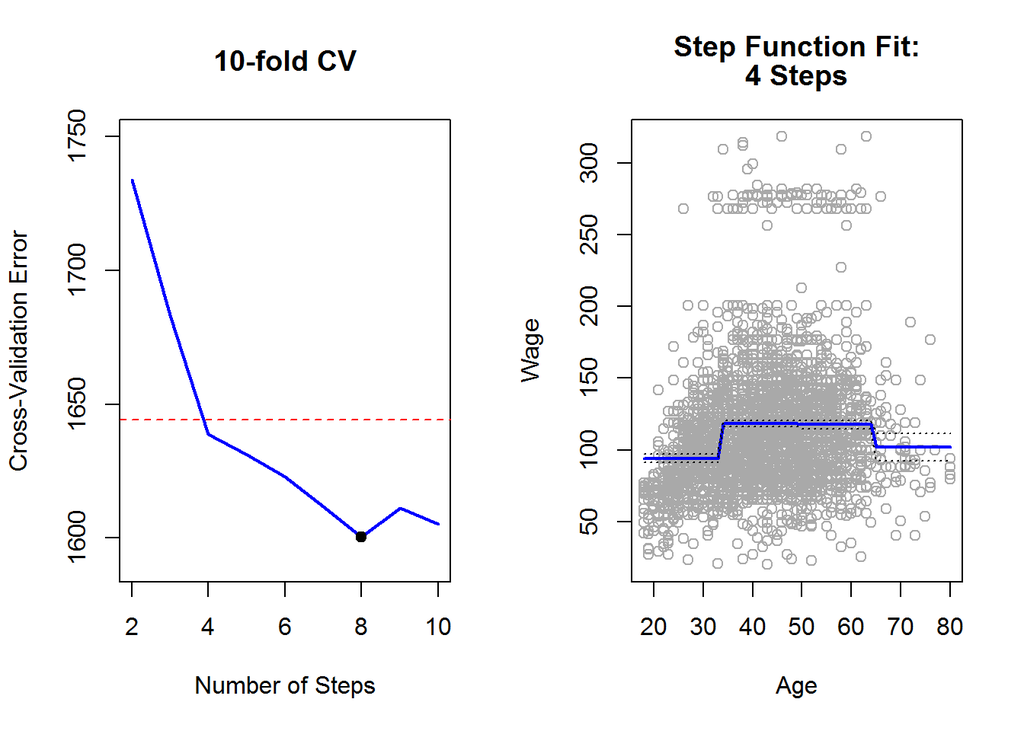

```r
par(mfrow=c(1,2))
minimum = min(cv.error.10, na.rm = T)
sdKfold = sd(cv.error.10, na.rm = T)

# Cross-Validation Plot
plot(2:10, cv.error.10[2:10], xlab="Number of Steps", ylab="Cross-Validation Error", type="l", pch=20, lwd=2, ylim=c(1590, 1750), col="blue", main = "10-fold CV")
abline(h = minimum + sdKfold, col="red", lty="dashed")
points(x = which.min(cv.error.10), y = minimum, pch=19)

# Step Function Fit Plot
lm.fit = glm(wage~cut(age, 4), data=Wage)
age.grid = seq(min(Wage$age), max(Wage$age))
preds = predict(lm.fit, data.frame(age=age.grid), se=TRUE)
se.bands = cbind(preds$fit + 2 * preds$se.fit, preds$fit - 2 * preds$se.fit)
plot(wage~age, data=Wage, col="darkgrey", xlab = "Age", ylab = "Wage", main = c("Step Function Fit:", "4 Steps"))
lines(age.grid, preds$fit, col="blue", lwd=2)
matlines(age.grid, se.bands, lwd = 1, col = "black", lty = 3)
```

Again, the optimal number of cuts was chosen using the 1 Standard Deviation Rule. Looking at the graph, it seems like there are only 3 steps, but checking for the steps we can see why:

```r
unique(preds$fit)
```

```
## [1]  94.15839 118.21188 117.82295 101.79898
```

```r
minimum + sdKfold
```

```
## [1] 1644.195
```

```r
cv.error.10[3:4]
```

```
## [1] 1683.181 1638.865
```

This happened because the fit at the third cut is very similar to the fit at the second cut.Yet the model with 3 Steps has a Cross-Validation error that is higher than the minimum cross validation error obtained plus one standard deviation. For this reason, the model with 3 steps was discarded.

**7)**

Basic statistics on the Wage dataset:

```r
summary(Wage)
```

```
##       year           age                     maritl           race
##  Min.   :2003   Min.   :18.00   1. Never Married: 648   1. White:2480
##  1st Qu.:2004   1st Qu.:33.75   2. Married      :2074   2. Black: 293
##  Median :2006   Median :42.00   3. Widowed      :  19   3. Asian: 190
##  Mean   :2006   Mean   :42.41   4. Divorced     : 204   4. Other:  37
##  3rd Qu.:2008   3rd Qu.:51.00   5. Separated    :  55
##  Max.   :2009   Max.   :80.00
##
##               education                     region
##  1. < HS Grad      :268   2. Middle Atlantic   :3000
##  2. HS Grad        :971   1. New England       :   0
##  3. Some College   :650   3. East North Central:   0
##  4. College Grad   :685   4. West North Central:   0
##  5. Advanced Degree:426   5. South Atlantic    :   0
##                           6. East South Central:   0
##                           (Other)              :   0
##            jobclass               health      health_ins      logwage
##  1. Industrial :1544   1. <=Good     : 858   1. Yes:2083   Min.   :3.000
##  2. Information:1456   2. >=Very Good:2142   2. No : 917   1st Qu.:4.447
##                                                            Median :4.653
##                                                            Mean   :4.654
##                                                            3rd Qu.:4.857
##                                                            Max.   :5.763
##
##       wage               age.cut
##  Min.   : 20.09   (42.8,49]  :640
##  1st Qu.: 85.38   (36.6,42.8]:542
##  Median :104.92   (30.4,36.6]:445
##  Mean   :111.70   (49,55.2]  :441
##  3rd Qu.:128.68   (24.2,30.4]:347
##  Max.   :318.34   (55.2,61.4]:270
##                   (Other)    :315
```

```r
str(Wage)
```

```
## 'data.frame':    3000 obs. of  12 variables:
##  $ year      : int  2006 2004 2003 2003 2005 2008 2009 2008 2006 2004 ...
##  $ age       : int  18 24 45 43 50 54 44 30 41 52 ...
##  $ maritl    : Factor w/ 5 levels "1. Never Married",..: 1 1 2 2 4 2 2 1 1 2 ...
##  $ race      : Factor w/ 4 levels "1. White","2. Black",..: 1 1 1 3 1 1 4 3 2 1 ...
##  $ education : Factor w/ 5 levels "1. < HS Grad",..: 1 4 3 4 2 4 3 3 3 2 ...
##  $ region    : Factor w/ 9 levels "1. New England",..: 2 2 2 2 2 2 2 2 2 2 ...
##  $ jobclass  : Factor w/ 2 levels "1. Industrial",..: 1 2 1 2 2 2 1 2 2 2 ...
##  $ health    : Factor w/ 2 levels "1. <=Good","2. >=Very Good": 1 2 1 2 1 2 2 1 2 2 ...
##  $ health_ins: Factor w/ 2 levels "1. Yes","2. No": 2 2 1 1 1 1 1 1 1 1 ...
##  $ logwage   : num  4.32 4.26 4.88 5.04 4.32 ...
##  $ wage      : num  75 70.5 131 154.7 75 ...
##  $ age.cut   : Factor w/ 10 levels "(17.9,24.2]",..: 1 1 5 5 6 6 5 2 4 6 ...
```

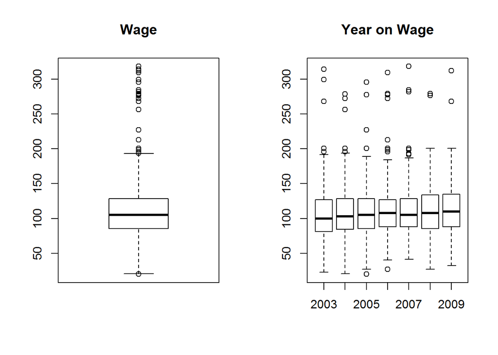

```r
par(mfrow = c(1,2))
boxplot(Wage$wage, main = "Wage", xlab = "", ylab = "")
boxplot(wage ~ year, data = Wage, main = "Year on Wage", xlab = "", ylab = "")
```

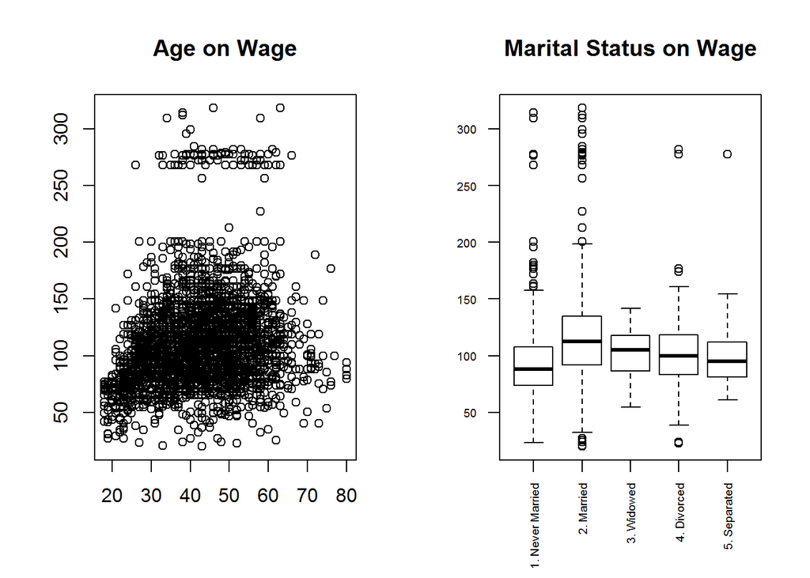

```r
plot(wage ~ age, data = Wage, main = "Age on Wage", xlab = "", ylab = "")
plot(wage ~ maritl, data = Wage, main = "Marital Status on Wage", las = 2, xlab = "", ylab = "", cex.axis = 0.6)
```

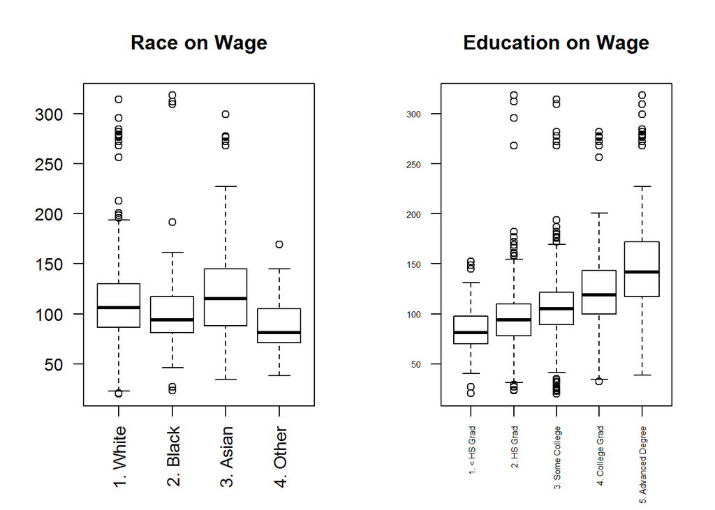

```r
plot(wage ~ race, data = Wage, main = "Race on Wage", xlab = "", ylab = "", las = 2)
plot(wage ~ education, data = Wage, main = "Education on Wage", xlab = "", ylab = "", las = 2, cex.axis = 0.5)
```

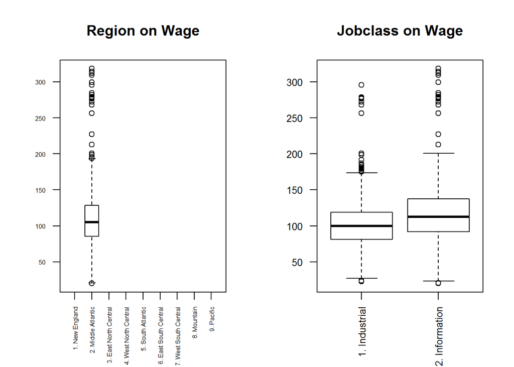

```r
plot(wage ~ region, data = Wage, main = "Region on Wage", xlab = "", ylab = "", las = 2, cex.axis = 0.5)
plot(wage ~ jobclass, data = Wage, main = "Jobclass on Wage", xlab = "", ylab = "", las = 2, cex.axis = 0.8)
```

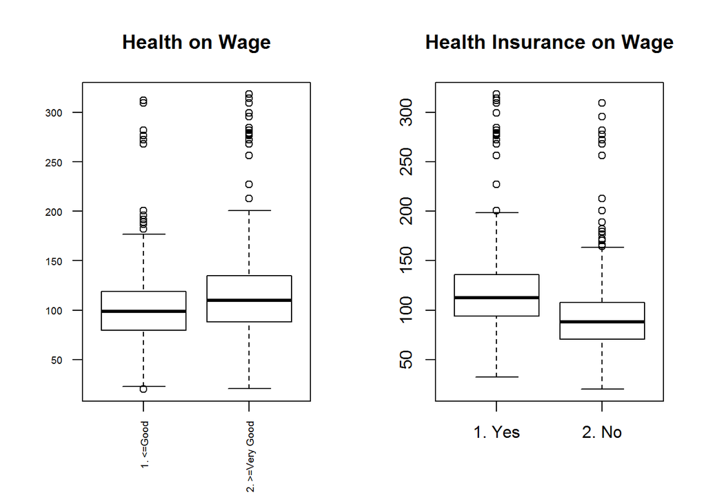

```r
plot(wage ~ health, data = Wage, main = "Health on Wage", xlab = "", ylab = "", las = 2, cex.axis = 0.6)
plot(wage ~ health_ins, data = Wage, main = "Health Insurance on Wage", xlab = "", ylab = "")
```

These previous stats shows us that there is no reason to consider the effects of region on Wage since all the data come from only one region.

### **Step Regression**

I’ll analyze the variable Year to see if it’s relation with Wage can be explained in a satisfactory manner by a step regression:  
Let’s use cross-validation to choose the most adequate number of steps:

```r
set.seed(1)
cv.error.10 = c()
for (i in 1:7) {
  if (i == 1) {
    lm.fit = glm(wage ~ year, data = Wage)
  } else {
    Wage$year.cut = cut(Wage$year, i)
    lm.fit = glm(wage ~ year.cut, data = Wage)
  }
  cv.error.10[i] = cv.glm(Wage, lm.fit, K=10)$delta[2]
}
cv.error.10
```

```
## [1] 1734.410 1738.861 1738.530 1739.655 1739.694 1742.041 1738.625
```

Plots the results:

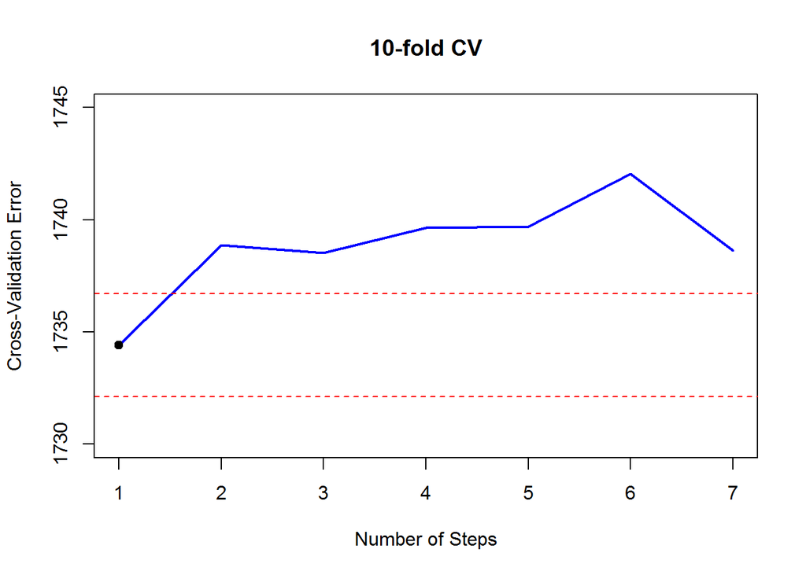

```r
minimum = min(cv.error.10, na.rm = T)
sdKfold = sd(cv.error.10, na.rm = T)

# Cross-Validation Plot
plot(1:7, cv.error.10[1:7], xlab="Number of Steps", ylab="Cross-Validation Error", type="l", pch=20, lwd=2, ylim=c(1730, 1745), col="blue", main = "10-fold CV")
abline(h = minimum + sdKfold, col="red", lty="dashed")
abline(h = minimum - sdKfold, col="red", lty="dashed")
points(x = which.min(cv.error.10), y = minimum, pch=19)
```

The Cross-Validation results shows that a linear model represents more accurately the relation between Year and Wage. For this reason, we won’t analyze this data with a step function.

### **GAM**

```r
fit = gam(wage ~ s(age, 2) + maritl + race + education + jobclass, data = Wage)
summary(fit)
```

```
##
## Call: gam(formula = wage ~ s(age, 2) + maritl + race + education +
##     jobclass, data = Wage)
## Deviance Residuals:
##      Min       1Q   Median       3Q      Max
## -112.258  -19.972   -2.993   14.351  214.657
##
## (Dispersion Parameter for gaussian family taken to be 1210.63)
##
##     Null Deviance: 5222086 on 2999 degrees of freedom
## Residual Deviance: 3613730 on 2985 degrees of freedom
## AIC: 29827.28
##
## Number of Local Scoring Iterations: 2
##
## Anova for Parametric Effects
##             Df  Sum Sq Mean Sq F value    Pr(>F)
## s(age, 2)    1  199870  199870 165.096 < 2.2e-16 ***
## maritl       4  181625   45406  37.506 < 2.2e-16 ***
## race         3   37568   12523  10.344 9.023e-07 ***
## education    4 1035390  258848 213.812 < 2.2e-16 ***
## jobclass     1   16570   16570  13.687 0.0002199 ***
## Residuals 2985 3613730    1211
## ---
## Signif. codes:  0 '***' 0.001 '**' 0.01 '*' 0.05 '.' 0.1 ' ' 1
##
## Anova for Nonparametric Effects
##             Npar Df Npar F     Pr(F)
## (Intercept)
## s(age, 2)         1 54.079 2.472e-13 ***
## maritl
## race
## education
## jobclass
## ---
## Signif. codes:  0 '***' 0.001 '**' 0.01 '*' 0.05 '.' 0.1 ' ' 1
```

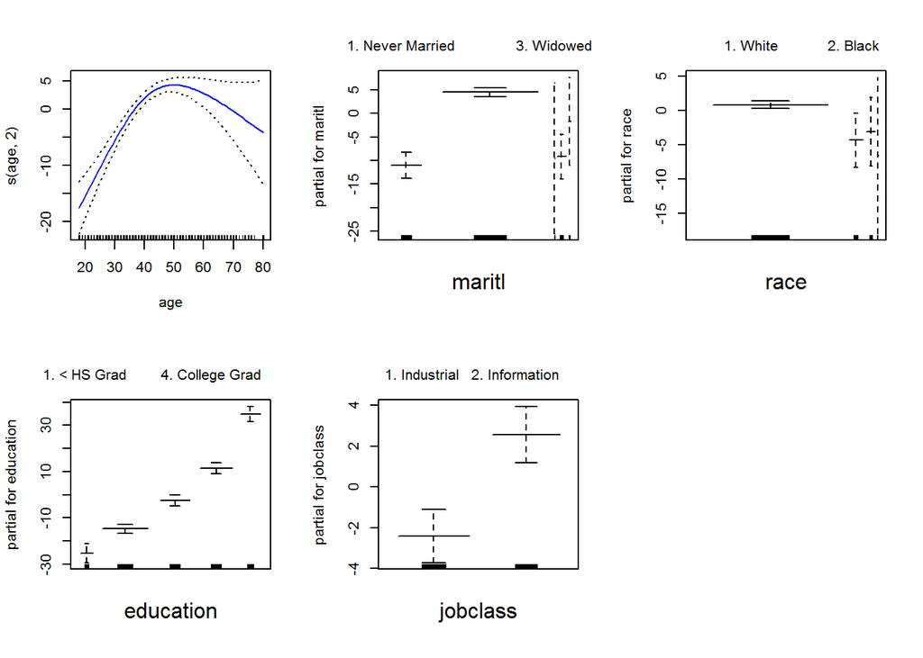

```r
par(mfrow = c(2, 3))
plot(fit, se = T, col = "blue")
```

This model shows some very interesting statistics:  
i) There is a quadratic relationship between age and salary;  
ii) People whom never got married have smaller wages than others;  
iii) Higher levels of education reflect on higher wages; and  
iv) Job class also has a relationship with wages levels. Industrial workers make less money.

**8)**

```r
str(Auto)
```

```
## 'data.frame':    392 obs. of  9 variables:
##  $ mpg         : num  18 15 18 16 17 15 14 14 14 15 ...
##  $ cylinders   : num  8 8 8 8 8 8 8 8 8 8 ...
##  $ displacement: num  307 350 318 304 302 429 454 440 455 390 ...
##  $ horsepower  : num  130 165 150 150 140 198 220 215 225 190 ...
##  $ weight      : num  3504 3693 3436 3433 3449 ...
##  $ acceleration: num  12 11.5 11 12 10.5 10 9 8.5 10 8.5 ...
##  $ year        : num  70 70 70 70 70 70 70 70 70 70 ...
##  $ origin      : num  1 1 1 1 1 1 1 1 1 1 ...
##  $ name        : Factor w/ 304 levels "amc ambassador brougham",..: 49 36 231 14 161 141 54 223 241 2 ...
```

```r
summary(Auto[,c(1:8)])
```

```
##       mpg          cylinders      displacement     horsepower
##  Min.   : 9.00   Min.   :3.000   Min.   : 68.0   Min.   : 46.0
##  1st Qu.:17.00   1st Qu.:4.000   1st Qu.:105.0   1st Qu.: 75.0
##  Median :22.75   Median :4.000   Median :151.0   Median : 93.5
##  Mean   :23.45   Mean   :5.472   Mean   :194.4   Mean   :104.5
##  3rd Qu.:29.00   3rd Qu.:8.000   3rd Qu.:275.8   3rd Qu.:126.0
##  Max.   :46.60   Max.   :8.000   Max.   :455.0   Max.   :230.0
##      weight      acceleration        year           origin
##  Min.   :1613   Min.   : 8.00   Min.   :70.00   Min.   :1.000
##  1st Qu.:2225   1st Qu.:13.78   1st Qu.:73.00   1st Qu.:1.000
##  Median :2804   Median :15.50   Median :76.00   Median :1.000
##  Mean   :2978   Mean   :15.54   Mean   :75.98   Mean   :1.577
##  3rd Qu.:3615   3rd Qu.:17.02   3rd Qu.:79.00   3rd Qu.:2.000
##  Max.   :5140   Max.   :24.80   Max.   :82.00   Max.   :3.000
```

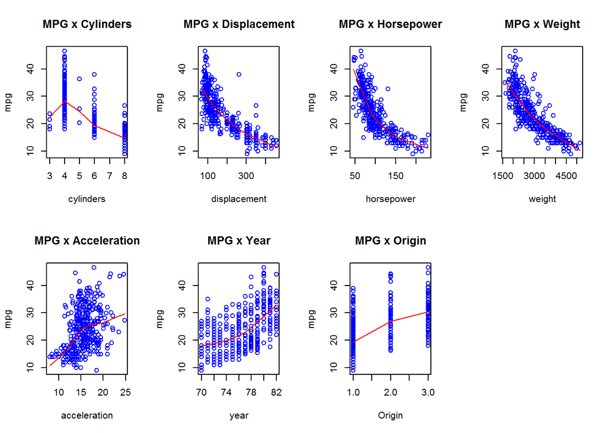

```r
par(mfrow = c(2,4))
plot(Auto$mpg ~ Auto$cylinders, xlab = "cylinders", ylab = "mpg", main = "MPG x Cylinders", col = "blue")
lines(lowess(Auto$cylinders, Auto$mpg), col = "red")
plot(Auto$mpg ~ Auto$displacement, xlab = "displacement", ylab = "mpg", main = "MPG x Displacement", col = "blue")
lines(lowess(Auto$displacement, Auto$mpg), col = "red")
plot(Auto$mpg ~ Auto$horsepower, xlab = "horsepower", ylab = "mpg", main = "MPG x Horsepower", col = "blue")
lines(lowess(Auto$horsepower, Auto$mpg), col = "red")
plot(Auto$mpg ~ Auto$weight, xlab = "weight", ylab = "mpg", main = "MPG x Weight", col = "blue")
lines(lowess(Auto$weight, Auto$mpg), col = "red")
plot(Auto$mpg ~ Auto$acceleration, xlab = "acceleration", ylab = "mpg", main = "MPG x Acceleration", col = "blue")
lines(lowess(Auto$acceleration, Auto$mpg), col = "red")
plot(Auto$mpg ~ Auto$year, xlab = "year", ylab = "mpg", main = "MPG x Year", col = "blue")
lines(lowess(Auto$year, Auto$mpg), col = "red")
plot(Auto$mpg ~ Auto$origin, xlab = "Origin", ylab = "mpg", main = "MPG x Origin", col = "blue")
lines(lowess(Auto$origin, Auto$mpg), col = "red")
```

Looking at the relation between mpg and the others variables, the graphs suggest that we could fit some non-linear models using the variables displacement, horsepower, weight, acceleration and year. We’ll test this claim by fitting some non-linear models using these variables:

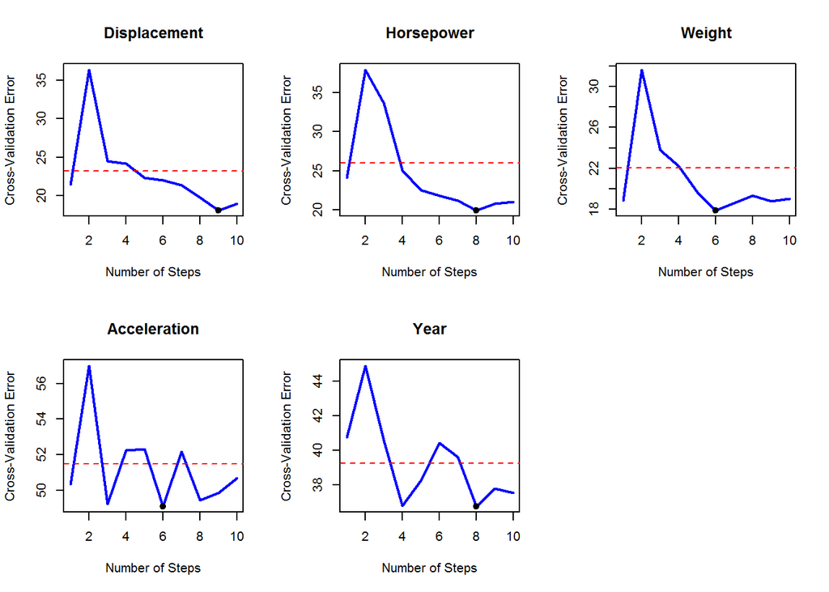

```r
par(mfrow = c(2,3))
# Displacement
set.seed(1)
cv.error.10 = c()
for(i in 1:10){
  if(i == 1){
    lm.fit = glm(mpg ~ displacement, data = Auto)
  } else {
    Auto$displacement.cut = cut(Auto$displacement, i)
    lm.fit = glm(mpg ~ displacement.cut, data = Auto)
  }
  cv.error.10[i] = cv.glm(Auto, lm.fit, K = 10)$delta[2]
}
minimum = min(cv.error.10)
sdKfold = sd(cv.error.10)

# Cross-Validation Plot
plot(1:10, cv.error.10, xlab="Number of Steps", ylab="Cross-Validation Error", type="l", pch=20, lwd=2, col="blue", main = "Displacement")
abline(h = minimum + sdKfold, col="red", lty="dashed")
points(x = which.min(cv.error.10), y = minimum, pch=19)


# Horsepower
set.seed(1)
cv.error.10 = c()
for(i in 1:10){
  if(i == 1){
    lm.fit = glm(mpg ~ horsepower, data = Auto)
  } else {
    Auto$horsepower.cut = cut(Auto$horsepower, i)
    lm.fit = glm(mpg ~ horsepower.cut, data = Auto)
  }
  cv.error.10[i] = cv.glm(Auto, lm.fit, K = 10)$delta[2]
}
minimum = min(cv.error.10)
sdKfold = sd(cv.error.10)

# Cross-Validation Plot
plot(1:10, cv.error.10, xlab="Number of Steps", ylab="Cross-Validation Error", type="l", pch=20, lwd=2, col="blue", main = "Horsepower")
abline(h = minimum + sdKfold, col="red", lty="dashed")
points(x = which.min(cv.error.10), y = minimum, pch=19)


# Weight
set.seed(1)
cv.error.10 = c()
for(i in 1:10){
  if(i == 1){
    lm.fit = glm(mpg ~ weight, data = Auto)
  } else {
    Auto$weight.cut = cut(Auto$weight, i)
    lm.fit = glm(mpg ~ weight.cut, data = Auto)
  }
  cv.error.10[i] = cv.glm(Auto, lm.fit, K = 10)$delta[2]
}
minimum = min(cv.error.10)
sdKfold = sd(cv.error.10)

# Cross-Validation Plot
plot(1:10, cv.error.10, xlab="Number of Steps", ylab="Cross-Validation Error", type="l", pch=20, lwd=2, col="blue", main = "Weight")
abline(h = minimum + sdKfold, col="red", lty="dashed")
points(x = which.min(cv.error.10), y = minimum, pch=19)


# Acceleration
set.seed(1)
cv.error.10 = c()
for(i in 1:10){
  if(i == 1){
    lm.fit = glm(mpg ~ acceleration, data = Auto)
  } else {
    Auto$acceleration.cut = cut(Auto$acceleration, i)
    lm.fit = glm(mpg ~ acceleration.cut, data = Auto)
  }
  cv.error.10[i] = cv.glm(Auto, lm.fit, K = 10)$delta[2]
}
minimum = min(cv.error.10)
sdKfold = sd(cv.error.10)

# Cross-Validation Plot
plot(1:10, cv.error.10, xlab="Number of Steps", ylab="Cross-Validation Error", type="l", pch=20, lwd=2, col="blue", main = "Acceleration")
abline(h = minimum + sdKfold, col="red", lty="dashed")
points(x = which.min(cv.error.10), y = minimum, pch=19)


# Year
set.seed(1)
cv.error.10 = c()
for(i in 1:10){
  if(i == 1){
    lm.fit = glm(mpg ~ year, data = Auto)
  } else {
    Auto$year.cut = cut(Auto$year, i)
    lm.fit = glm(mpg ~ year.cut, data = Auto)
  }
  cv.error.10[i] = cv.glm(Auto, lm.fit, K = 10)$delta[2]
}
minimum = min(cv.error.10)
sdKfold = sd(cv.error.10)

# Cross-Validation Plot
plot(1:10, cv.error.10, xlab="Number of Steps", ylab="Cross-Validation Error", type="l", pch=20, lwd=2, col="blue", main = "Year")
abline(h = minimum + sdKfold, col="red", lty="dashed")
points(x = which.min(cv.error.10), y = minimum, pch=19)
```

The cross-validation error plots shows that althought the best fit for all the variables has more than one step, a linear model would still be a good model to measure the relation between mpg and these variables. The only exception would be the variable year. For this variable we can see that the simplest model that would give us a good fit is a step regression with 4 steps.

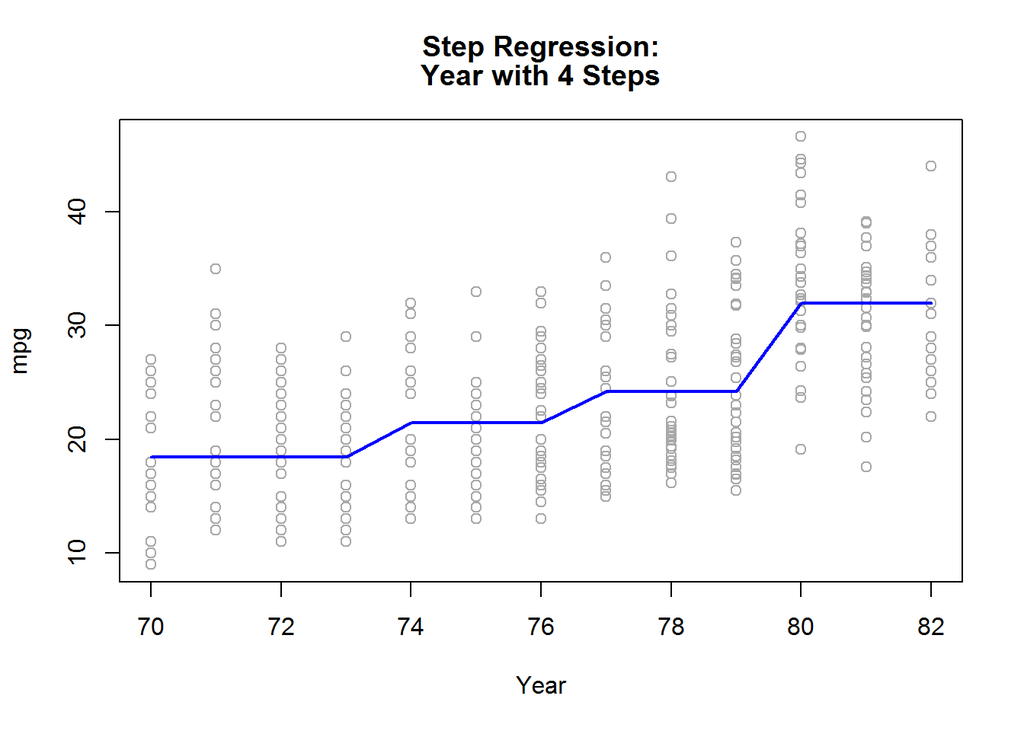

```r
lm.fit = glm(mpg~cut(year, 4), data=Auto)
year.grid = seq(min(Auto$year), max(Auto$year))
preds = predict(lm.fit, data.frame(year=year.grid))
plot(mpg~year, data=Auto, col="darkgrey", xlab = "Year", ylab = "mpg", main = c("Step Regression:", "Year with 4 Steps"))
lines(year.grid, preds, col="blue", lwd=2)
```

We’ll now fit some polynomial models to the data:

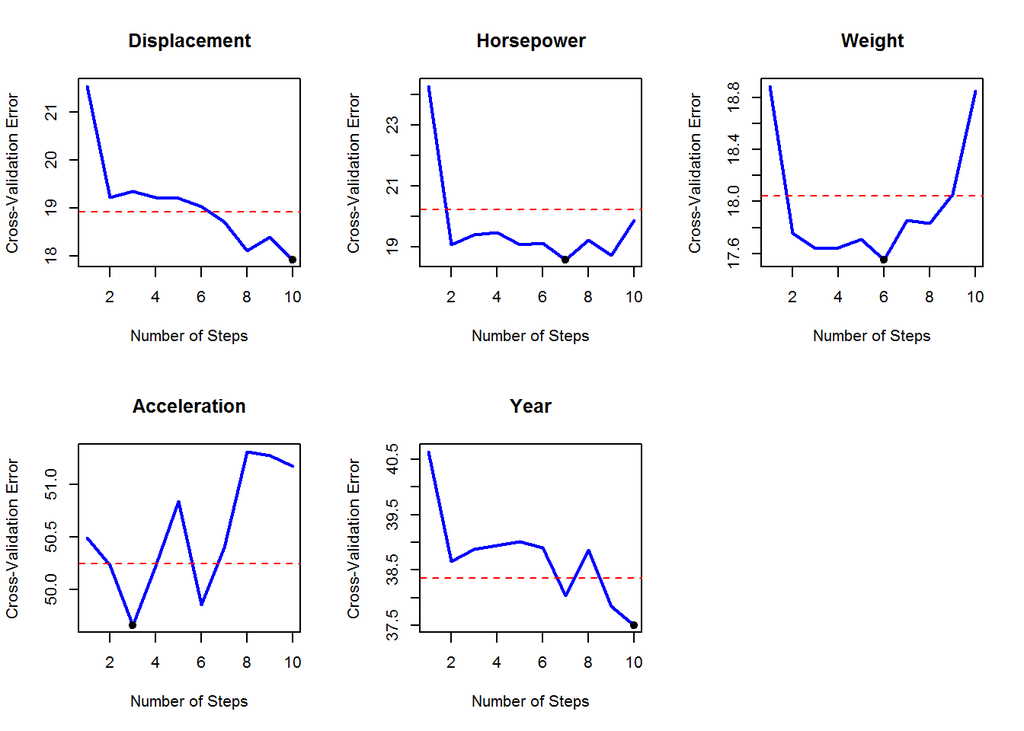

```r
par(mfrow = c(2,3))

# Displacement
cv.error.10 <- c()
for (i in 1:10) {
  fit = glm(mpg ~ poly(displacement, i), data = Auto)
  cv.error.10[i] = cv.glm(Auto, fit, K = 10)$delta[1]
}
minimum = min(cv.error.10)
sdKfold = sd(cv.error.10)

plot(1:10, cv.error.10, xlab="Number of Steps", ylab="Cross-Validation Error", type="l", pch=20, lwd=2, col="blue", main = "Displacement")
abline(h = minimum + sdKfold, col="red", lty="dashed")
points(x = which.min(cv.error.10), y = minimum, pch=19)

# Horsepower
cv.error.10 <- c()
for (i in 1:10) {
  fit = glm(mpg ~ poly(horsepower, i), data = Auto)
  cv.error.10[i] = cv.glm(Auto, fit, K = 10)$delta[1]
}
minimum = min(cv.error.10)
sdKfold = sd(cv.error.10)

plot(1:10, cv.error.10, xlab="Number of Steps", ylab="Cross-Validation Error", type="l", pch=20, lwd=2, col="blue", main = "Horsepower")
abline(h = minimum + sdKfold, col="red", lty="dashed")
points(x = which.min(cv.error.10), y = minimum, pch=19)

# Weight
cv.error.10 <- c()
for (i in 1:10) {
  fit = glm(mpg ~ poly(weight, i), data = Auto)
  cv.error.10[i] = cv.glm(Auto, fit, K = 10)$delta[1]
}
minimum = min(cv.error.10)
sdKfold = sd(cv.error.10)

plot(1:10, cv.error.10, xlab="Number of Steps", ylab="Cross-Validation Error", type="l", pch=20, lwd=2, col="blue", main = "Weight")
abline(h = minimum + sdKfold, col="red", lty="dashed")
points(x = which.min(cv.error.10), y = minimum, pch=19)

# Acceleration
cv.error.10 <- c()
for (i in 1:10) {
  fit = glm(mpg ~ poly(acceleration, i), data = Auto)
  cv.error.10[i] = cv.glm(Auto, fit, K = 10)$delta[1]
}
minimum = min(cv.error.10)
sdKfold = sd(cv.error.10)

plot(1:10, cv.error.10, xlab="Number of Steps", ylab="Cross-Validation Error", type="l", pch=20, lwd=2, col="blue", main = "Acceleration")
abline(h = minimum + sdKfold, col="red", lty="dashed")
points(x = which.min(cv.error.10), y = minimum, pch=19)

# Year
cv.error.10 <- c()
for (i in 1:10) {
  fit = glm(mpg ~ poly(year, i), data = Auto)
  cv.error.10[i] = cv.glm(Auto, fit, K = 10)$delta[1]
}
minimum = min(cv.error.10)
sdKfold = sd(cv.error.10)

plot(1:10, cv.error.10, xlab="Number of Steps", ylab="Cross-Validation Error", type="l", pch=20, lwd=2, col="blue", main = "Year")
abline(h = minimum + sdKfold, col="red", lty="dashed")
points(x = which.min(cv.error.10), y = minimum, pch=19)
```

Comparing these graphs with the previous we can see that polynomial models present better fit to the Auto data than a linear model. Using the polynomials degrees that best fits the data we produced the following graphs:

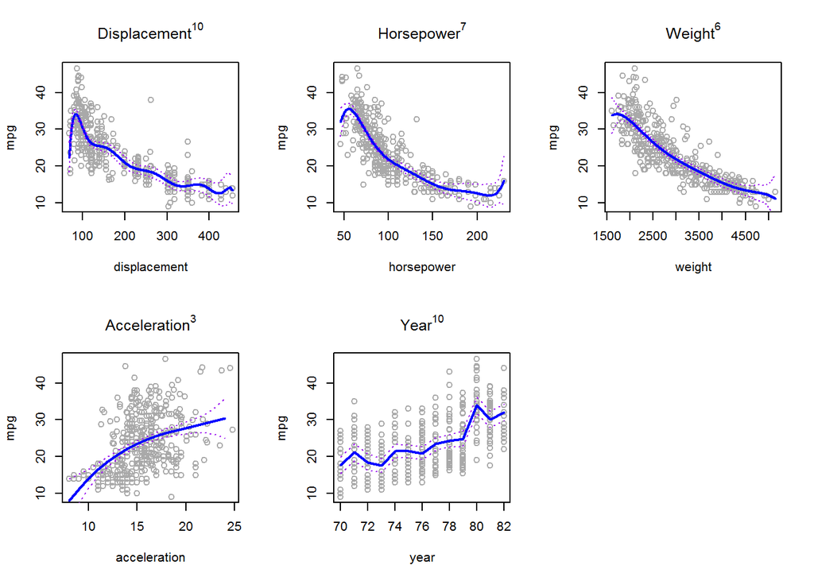

```r
par(mfrow = c(2,3))
# Displacement
displacement.grid = seq(min(Auto$displacement), max(Auto$displacement))
fit = lm(mpg ~ poly(displacement, 10), data=Auto)
preds = predict(fit, data.frame(displacement=displacement.grid), se=TRUE)
se.bands = cbind(preds$fit + 2 * preds$se.fit, preds$fit - 2 * preds$se.fit)
plot(mpg ~ displacement, data = Auto, col = "darkgrey", xlab = "displacement", ylab = "mpg", main=expression("Displacement"^"10"))
lines(displacement.grid, preds$fit, lwd = 2, col = "blue")
matlines(displacement.grid, se.bands, lwd = 1, col = "purple", lty = 3)

# Horsepower
horsepower.grid = seq(min(Auto$horsepower), max(Auto$horsepower))
fit = lm(mpg ~ poly(horsepower, 7), data=Auto)
preds = predict(fit, data.frame(horsepower=horsepower.grid), se=TRUE)
se.bands = cbind(preds$fit + 2 * preds$se.fit, preds$fit - 2 * preds$se.fit)
plot(mpg ~ horsepower, data = Auto, col = "darkgrey", xlab = "horsepower", ylab = "mpg", main=expression("Horsepower"^"7"))
lines(horsepower.grid, preds$fit, lwd = 2, col = "blue")
matlines(horsepower.grid, se.bands, lwd = 1, col = "purple", lty = 3)

# Weight
weight.grid = seq(min(Auto$weight), max(Auto$weight))
fit = lm(mpg ~ poly(weight, 6), data=Auto)
preds = predict(fit, data.frame(weight=weight.grid), se=TRUE)
se.bands = cbind(preds$fit + 2 * preds$se.fit, preds$fit - 2 * preds$se.fit)
plot(mpg ~ weight, data = Auto, col = "darkgrey", xlab = "weight", ylab = "mpg", main=expression("Weight"^"6"))
lines(weight.grid, preds$fit, lwd = 2, col = "blue")
matlines(weight.grid, se.bands, lwd = 1, col = "purple", lty = 3)

# Acceleration
acceleration.grid = seq(min(Auto$acceleration), max(Auto$acceleration))
fit = lm(mpg ~ poly(acceleration, 3), data=Auto)
preds = predict(fit, data.frame(acceleration=acceleration.grid), se=TRUE)
se.bands = cbind(preds$fit + 2 * preds$se.fit, preds$fit - 2 * preds$se.fit)
plot(mpg ~ acceleration, data = Auto, col = "darkgrey", xlab = "acceleration", ylab = "mpg", main=expression("Acceleration"^"3"))
lines(acceleration.grid, preds$fit, lwd = 2, col = "blue")
matlines(acceleration.grid, se.bands, lwd = 1, col = "purple", lty = 3)

# Year
year.grid = seq(min(Auto$year), max(Auto$year))
fit = lm(mpg ~ poly(year, 10), data=Auto)
preds = predict(fit, data.frame(year = year.grid), se=TRUE)
se.bands = cbind(preds$fit + 2 * preds$se.fit, preds$fit - 2 * preds$se.fit)
plot(mpg ~ year, data = Auto, col = "darkgrey", xlab = "year", ylab = "mpg", main = expression("Year"^"10"))
lines(year.grid, preds$fit, lwd = 2, col = "blue")
matlines(year.grid, se.bands, lwd = 1, col = "purple", lty = 3)
```

The previous graphs shows that the best fits to the data are non-linear.

**9)** **a)**

```r
fit = lm(nox ~ poly(dis, 3), data = Boston)
summary(fit)
```

```
##
## Call:
## lm(formula = nox ~ poly(dis, 3), data = Boston)
##
## Residuals:
##       Min        1Q    Median        3Q       Max
## -0.121130 -0.040619 -0.009738  0.023385  0.194904
##
## Coefficients:
##                Estimate Std. Error t value Pr(>|t|)
## (Intercept)    0.554695   0.002759 201.021  < 2e-16 ***
## poly(dis, 3)1 -2.003096   0.062071 -32.271  < 2e-16 ***
## poly(dis, 3)2  0.856330   0.062071  13.796  < 2e-16 ***
## poly(dis, 3)3 -0.318049   0.062071  -5.124 4.27e-07 ***
## ---
## Signif. codes:  0 '***' 0.001 '**' 0.01 '*' 0.05 '.' 0.1 ' ' 1
##
## Residual standard error: 0.06207 on 502 degrees of freedom
## Multiple R-squared:  0.7148, Adjusted R-squared:  0.7131
## F-statistic: 419.3 on 3 and 502 DF,  p-value: < 2.2e-16
```

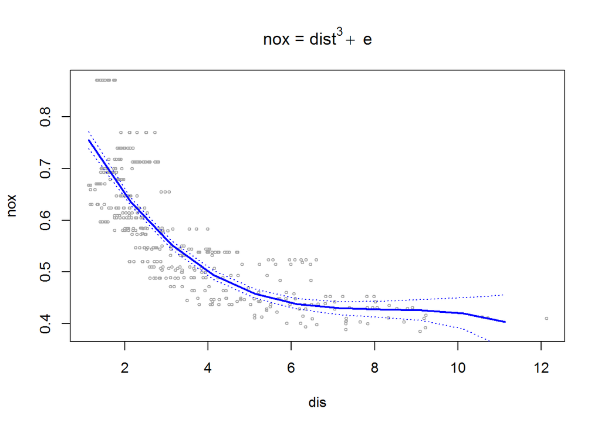

```r
# Plot
dis.grid = seq(from = min(Boston$dis), to = max(Boston$dis))
preds = predict(fit, newdata = list(dis = dis.grid), se=TRUE)
se.bands = cbind(preds$fit + 2 * preds$se.fit, preds$fit - 2 * preds$se.fit)
plot(Boston$dis, Boston$nox, xlim = c(min(Boston$dis), max(Boston$dis)), cex = 0.5, col = "darkgrey", xlab = "dis", ylab = "nox", main = expression("nox = dist"^"3"+" e"))
lines(dis.grid, preds$fit, lwd = 2, col = "blue")
matlines(dis.grid, se.bands, lwd = 1, col = "blue", lty = 3)
```

**b)**

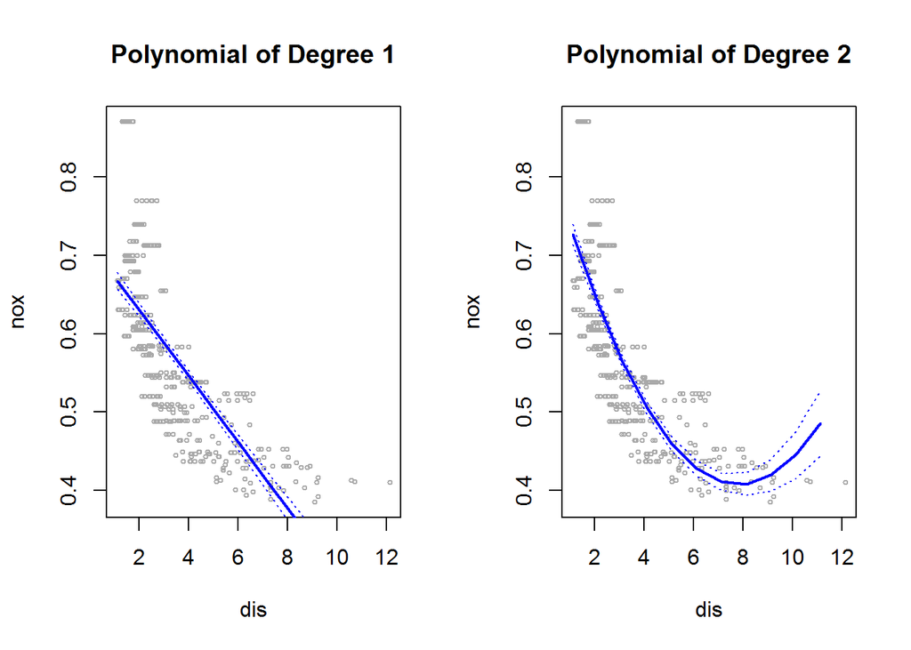

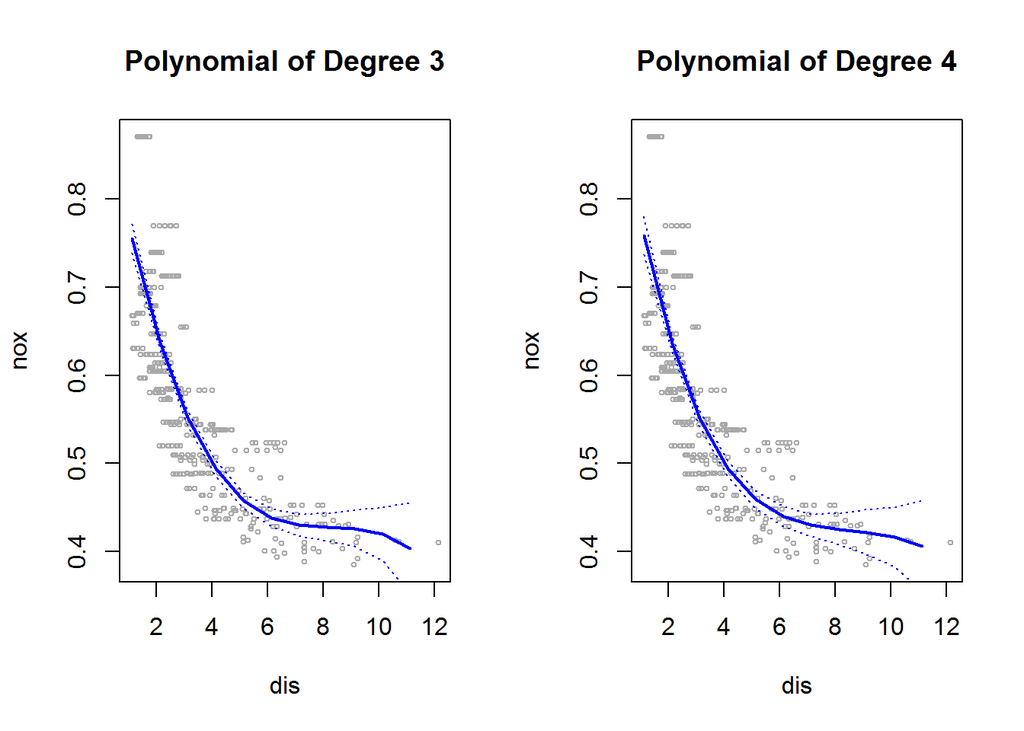

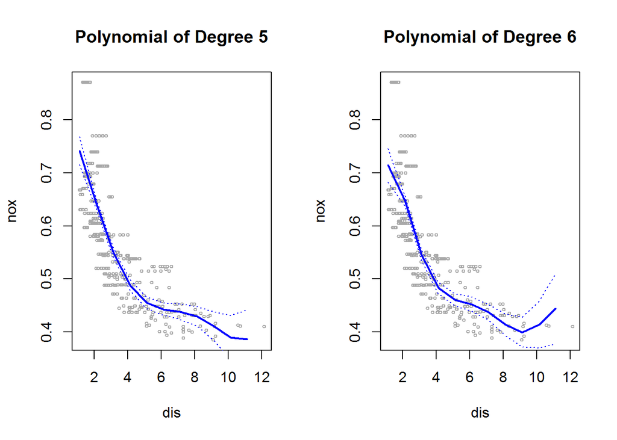

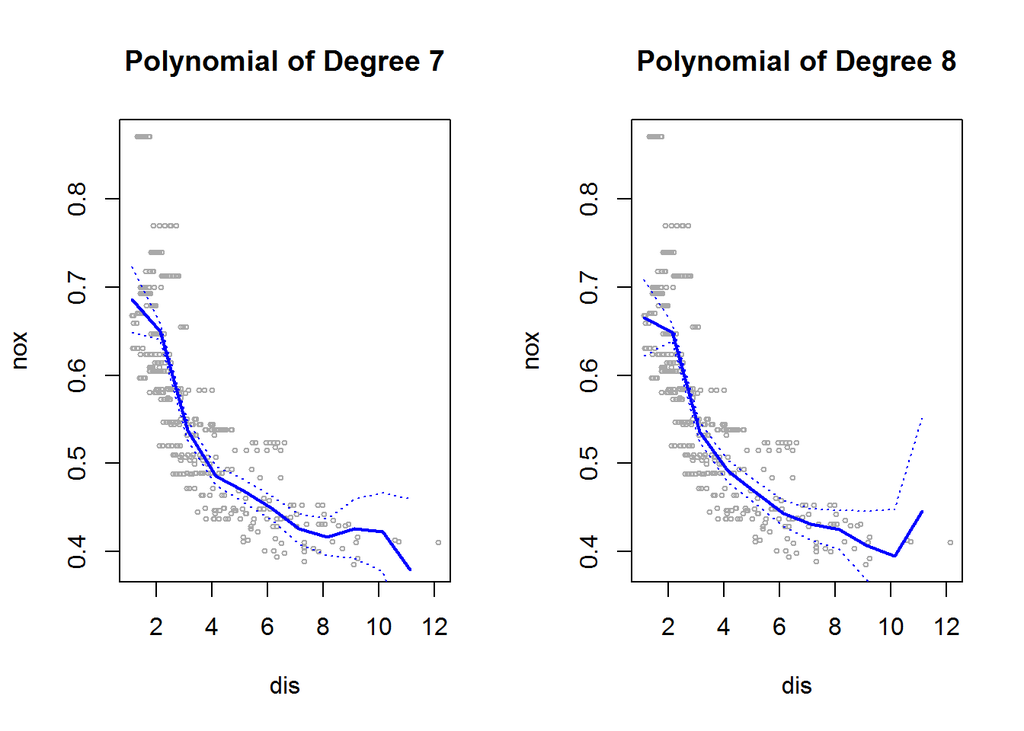

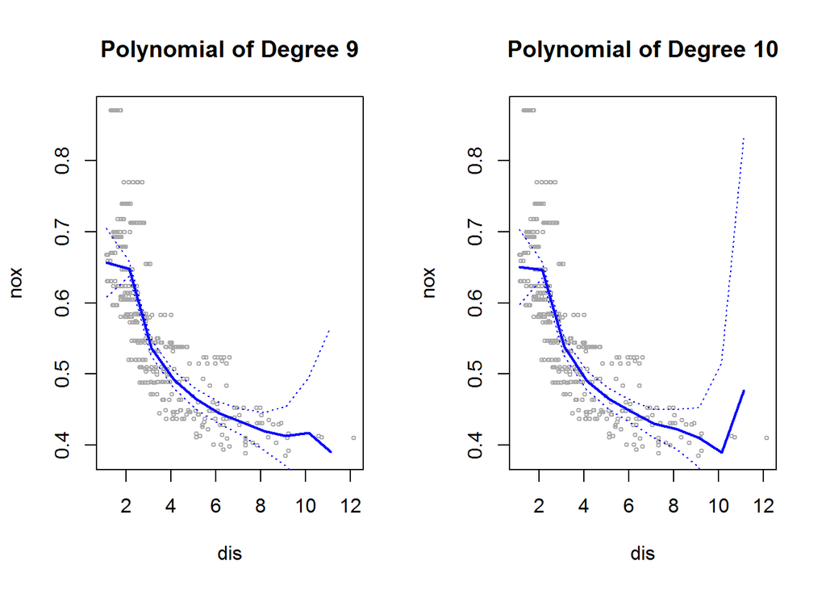

```r
par(mfrow = c(1, 2))
sqresiduals = c()
dis.grid = seq(from = min(Boston$dis), to = max(Boston$dis))
for (i in 1:10) {
  fit = lm(nox ~ poly(dis, i), data = Boston)
  preds = predict(fit, newdata = list(dis=dis.grid), se = TRUE)
  se.bands = cbind(preds$fit + 2 * preds$se.fit, preds$fit - 2 * preds$se.fit)
  plot(Boston$dis, Boston$nox, xlim = c(min(Boston$dis), max(Boston$dis)), cex = 0.5, col = "darkgrey", xlab = "dis", ylab = "nox", main = paste("Polynomial of Degree", i))
  lines(dis.grid, preds$fit, lwd = 2, col = "blue")
  matlines(dis.grid, se.bands, lwd = 1, col = "blue", lty = 3)
  sqresiduals[i] = sum(fit$residuals^2)
}
```

```r
sqresiduals
```

```
##  [1] 2.768563 2.035262 1.934107 1.932981 1.915290 1.878257 1.849484
##  [8] 1.835630 1.833331 1.832171
```

As expected, the model with the biggest polynomial is the one with the smallest RSS, since the model with the polynomial of degree 10 is the more flexible model and, for this reason, it adapts better to the sample.

**c)**

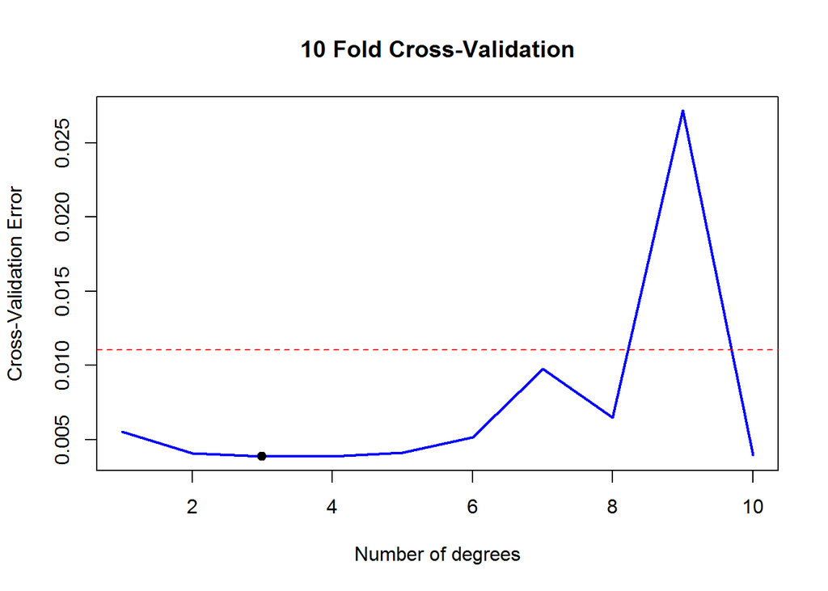

```r
cv.error.10 = c()
for (i in 1:10){
  fit = glm(nox ~ poly(dis, i), data = Boston)
  cv.error.10[i] = cv.glm(Boston, fit, K = 10)$delta[2]
}
minimum = min(cv.error.10)
sdKfold = sd(cv.error.10)

plot(1:10, cv.error.10, xlab="Number of degrees", ylab="Cross-Validation Error", type="l", pch=20, lwd=2, col="blue", main = "10 Fold Cross-Validation")
abline(h = minimum + sdKfold, col="red", lty="dashed")
points(x = which.min(cv.error.10), y = minimum, pch=19)
```

```r
cv.error.10
```

```
##  [1] 0.005540360 0.004069027 0.003872247 0.003894884 0.004109701
##  [6] 0.005156024 0.009755432 0.006498960 0.027180493 0.003983566
```

We can see that the best model, the one with the smallest cross-validation error, is the one with a third degree polynomial. However, the standard error of the cv errors suggests us that a linear model could also provide a good fit to predict the values of nox, since its cv error is within a 1-standard error distance from the model with the smallest cv-error.

**d)**

```r
fit = lm(nox ~ bs(dis, df = 4), data = Boston)
summary(fit)
```

```
##
## Call:
## lm(formula = nox ~ bs(dis, df = 4), data = Boston)
##
## Residuals:
##       Min        1Q    Median        3Q       Max
## -0.124622 -0.039259 -0.008514  0.020850  0.193891
##
## Coefficients:
##                  Estimate Std. Error t value Pr(>|t|)
## (Intercept)       0.73447    0.01460  50.306  < 2e-16 ***
## bs(dis, df = 4)1 -0.05810    0.02186  -2.658  0.00812 **
## bs(dis, df = 4)2 -0.46356    0.02366 -19.596  < 2e-16 ***
## bs(dis, df = 4)3 -0.19979    0.04311  -4.634 4.58e-06 ***
## bs(dis, df = 4)4 -0.38881    0.04551  -8.544  < 2e-16 ***
## ---
## Signif. codes:  0 '***' 0.001 '**' 0.01 '*' 0.05 '.' 0.1 ' ' 1
##
## Residual standard error: 0.06195 on 501 degrees of freedom
## Multiple R-squared:  0.7164, Adjusted R-squared:  0.7142
## F-statistic: 316.5 on 4 and 501 DF,  p-value: < 2.2e-16
```

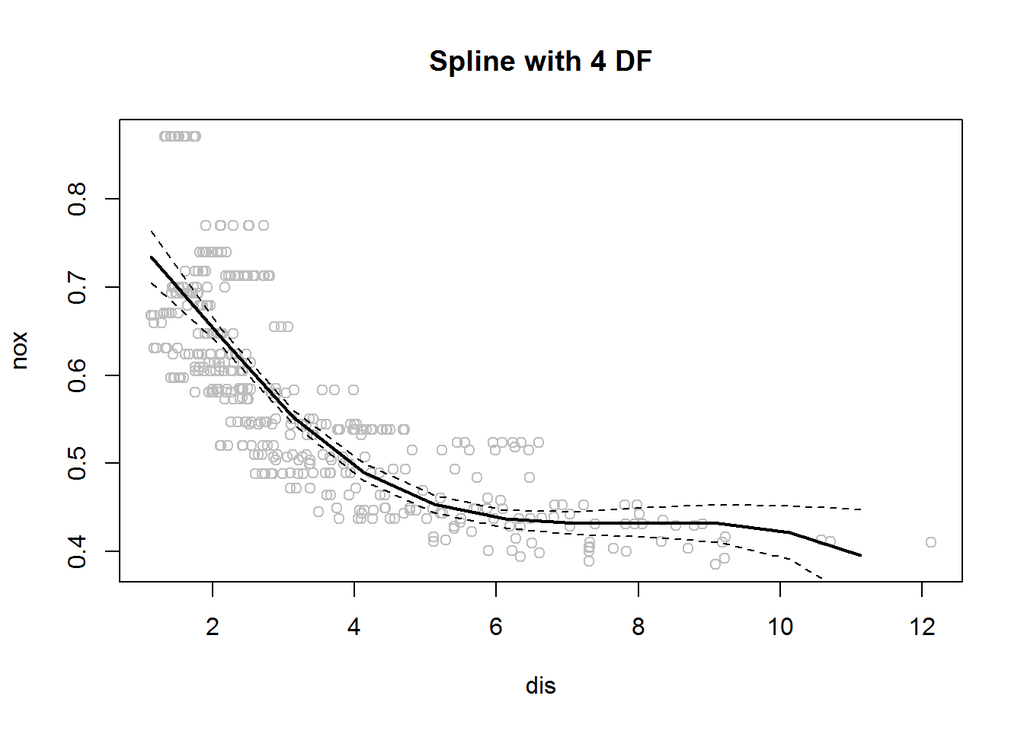

```r
# Plot
dis.grid = seq(min(Boston$dis), max(Boston$dis))
pred = predict(fit, newdata = list(dis = dis.grid), se=T)
plot(Boston$dis, Boston$nox, col = "gray", xlab = "dis", ylab = "nox", main = "Spline with 4 DF")
lines(dis.grid, pred$fit, lwd = 2)
lines(dis.grid, pred$fit + 2 * pred$se, lty = "dashed")
lines(dis.grid, pred$fit - 2 * pred$se, lty = "dashed")
```

In this model the knots were chosen to be equidistant. So all of them stay in a certain distance from the next and the previous one.

**e)**

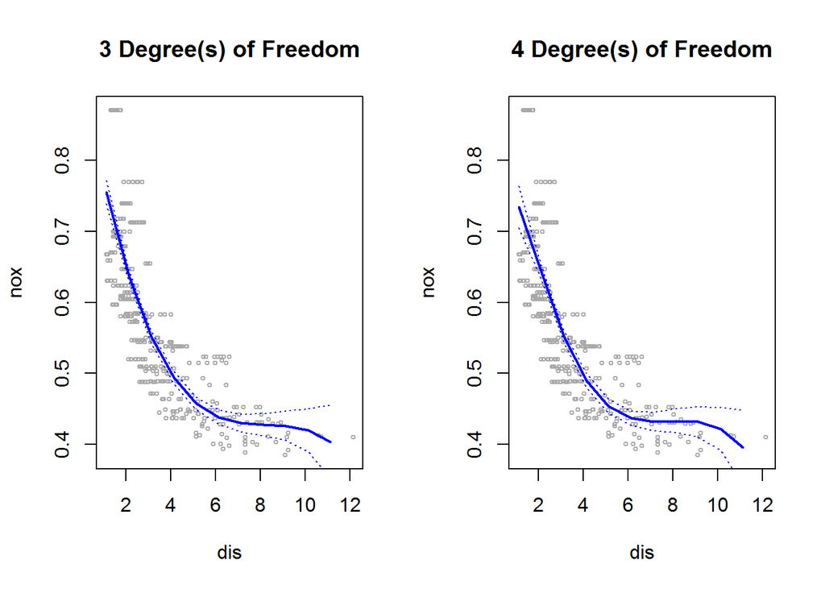

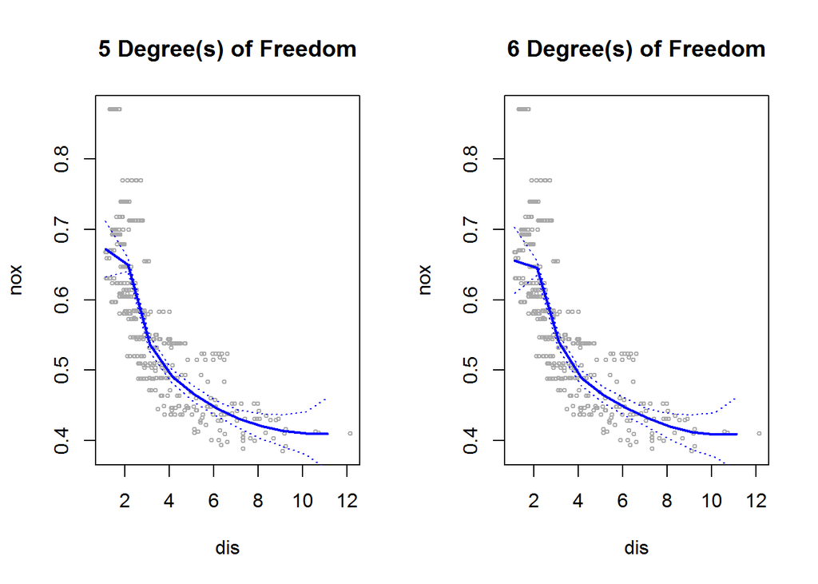

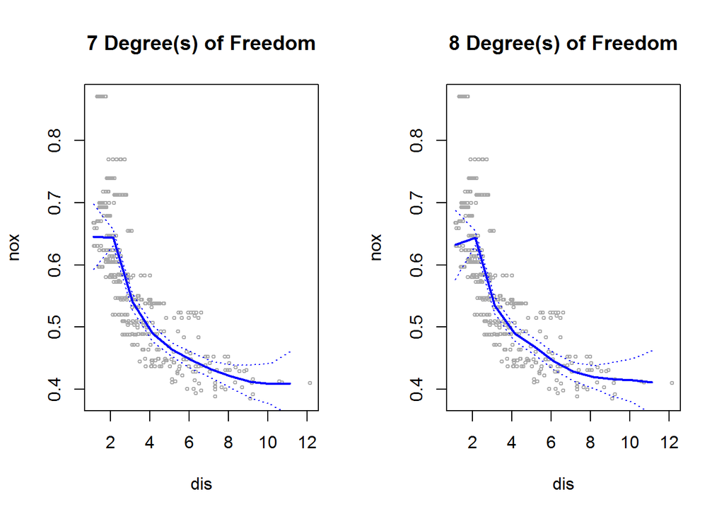

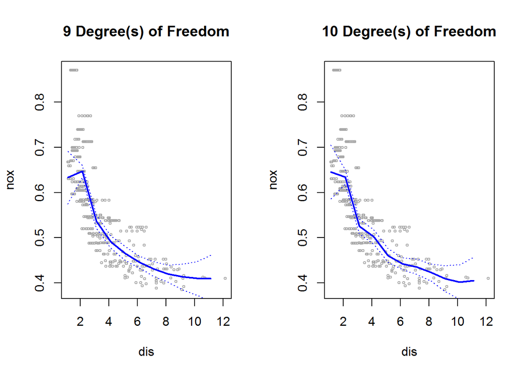

```r
par(mfrow = c(1, 2))
sqresiduals = c()
dis.grid = seq(from = min(Boston$dis), to = max(Boston$dis))
for (i in 3:10){
  fit = lm(nox ~ bs(dis, df = i), data = Boston)
  preds = predict(fit, newdata = list(dis=dis.grid), se = TRUE)
  se.bands = cbind(preds$fit + 2 * preds$se.fit, preds$fit - 2 * preds$se.fit)
  plot(Boston$dis, Boston$nox, xlim = c(min(Boston$dis), max(Boston$dis)), cex = 0.5, col = "darkgrey", xlab = "dis", ylab = "nox", main = paste(i, "Degree(s) of Freedom"))
  lines(dis.grid, preds$fit, lwd = 2, col = "blue")
  matlines(dis.grid, se.bands, lwd = 1, col = "blue", lty = 3)
  sqresiduals[i-2] = sum(fit$residuals^2)
}
```

```r
sqresiduals
```

```
## [1] 1.934107 1.922775 1.840173 1.833966 1.829884 1.816995 1.825653 1.792535
```

We see that the model with the biggest number of degrees of freedom is the one with the smallest RSS. However, this doesn’t say much about how good the model is to make predictions, since the model with the smallest RSS is the one more likely to be overfitting the data.

**f)**

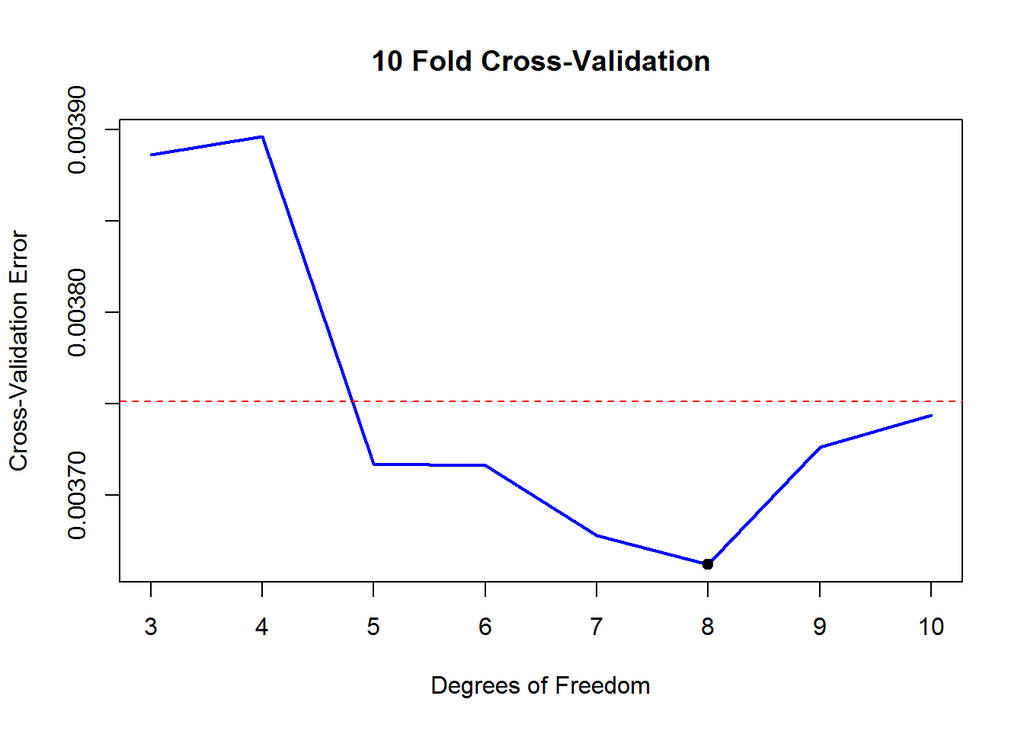

```r
cv.error.10 = c()
suppressWarnings(for (i in 3:10){
  fit = glm(nox ~ bs(dis, df = i), data = Boston)
  cv.error.10[i-2] = cv.glm(Boston, fit, K = 10)$delta[2]
})
minimum = min(cv.error.10)
sdKfold = sd(cv.error.10)

plot(3:10, cv.error.10, xlab="Degrees of Freedom", ylab="Cross-Validation Error", type="l", pch=20, lwd=2, col="blue", main = "10 Fold Cross-Validation")
abline(h = minimum + sdKfold, col="red", lty="dashed")
points(x = which.min(cv.error.10) + 2, y = minimum, pch=19)
```

```r
cv.error.10
```

```
## [1] 0.003886291 0.003896028 0.003717143 0.003716072 0.003677845 0.003661955
## [7] 0.003726117 0.003743861
```

The model with 8 degrees of freedom is the one with the smallest cross-validation error, but we can see in the plot that the model with 5 degrees of freedom could also be used since its cv error is within a 1 standard deviation distance from the smallest cv error found.

**10)** **a)**

```r
train = College[seq(1, nrow(College), 2),]
test = College[seq(2, nrow(College), 2),]
```

```r
fselection = regsubsets(Outstate ~ ., data = train, nvmax = 17, method = "forward")
fselection.summary = summary(fselection)
fselection.summary
```

```
## Subset selection object
## Call: regsubsets.formula(Outstate ~ ., data = train, nvmax = 17, method = "forward")
## 17 Variables  (and intercept)
##             Forced in Forced out
## PrivateYes      FALSE      FALSE
## Apps            FALSE      FALSE
## Accept          FALSE      FALSE
## Enroll          FALSE      FALSE
## Top10perc       FALSE      FALSE
## Top25perc       FALSE      FALSE
## F.Undergrad     FALSE      FALSE
## P.Undergrad     FALSE      FALSE
## Room.Board      FALSE      FALSE
## Books           FALSE      FALSE
## Personal        FALSE      FALSE
## PhD             FALSE      FALSE
## Terminal        FALSE      FALSE
## S.F.Ratio       FALSE      FALSE
## perc.alumni     FALSE      FALSE
## Expend          FALSE      FALSE
## Grad.Rate       FALSE      FALSE
## 1 subsets of each size up to 17
## Selection Algorithm: forward
##           PrivateYes Apps Accept Enroll Top10perc Top25perc F.Undergrad
## 1  ( 1 )  " "        " "  " "    " "    " "       " "       " "
## 2  ( 1 )  "*"        " "  " "    " "    " "       " "       " "
## 3  ( 1 )  "*"        " "  " "    " "    " "       " "       " "
## 4  ( 1 )  "*"        " "  " "    " "    " "       " "       " "
## 5  ( 1 )  "*"        " "  " "    " "    " "       " "       " "
## 6  ( 1 )  "*"        " "  " "    " "    " "       " "       " "
## 7  ( 1 )  "*"        " "  "*"    " "    " "       " "       " "
## 8  ( 1 )  "*"        " "  "*"    " "    " "       " "       "*"
## 9  ( 1 )  "*"        " "  "*"    " "    "*"       " "       "*"
## 10  ( 1 ) "*"        "*"  "*"    " "    "*"       " "       "*"
## 11  ( 1 ) "*"        "*"  "*"    " "    "*"       "*"       "*"
## 12  ( 1 ) "*"        "*"  "*"    " "    "*"       "*"       "*"
## 13  ( 1 ) "*"        "*"  "*"    "*"    "*"       "*"       "*"
## 14  ( 1 ) "*"        "*"  "*"    "*"    "*"       "*"       "*"
## 15  ( 1 ) "*"        "*"  "*"    "*"    "*"       "*"       "*"
## 16  ( 1 ) "*"        "*"  "*"    "*"    "*"       "*"       "*"
```

[output cut: 22 more lines]

```
## 3  ( 1 )  " "         "*"    " "
## 4  ( 1 )  " "         "*"    "*"
## 5  ( 1 )  " "         "*"    "*"
## 6  ( 1 )  "*"         "*"    "*"
## 7  ( 1 )  "*"         "*"    "*"
## 8  ( 1 )  "*"         "*"    "*"
## 9  ( 1 )  "*"         "*"    "*"
## 10  ( 1 ) "*"         "*"    "*"
## 11  ( 1 ) "*"         "*"    "*"
## 12  ( 1 ) "*"         "*"    "*"
## 13  ( 1 ) "*"         "*"    "*"
## 14  ( 1 ) "*"         "*"    "*"
## 15  ( 1 ) "*"         "*"    "*"
## 16  ( 1 ) "*"         "*"    "*"
## 17  ( 1 ) "*"         "*"    "*"
```

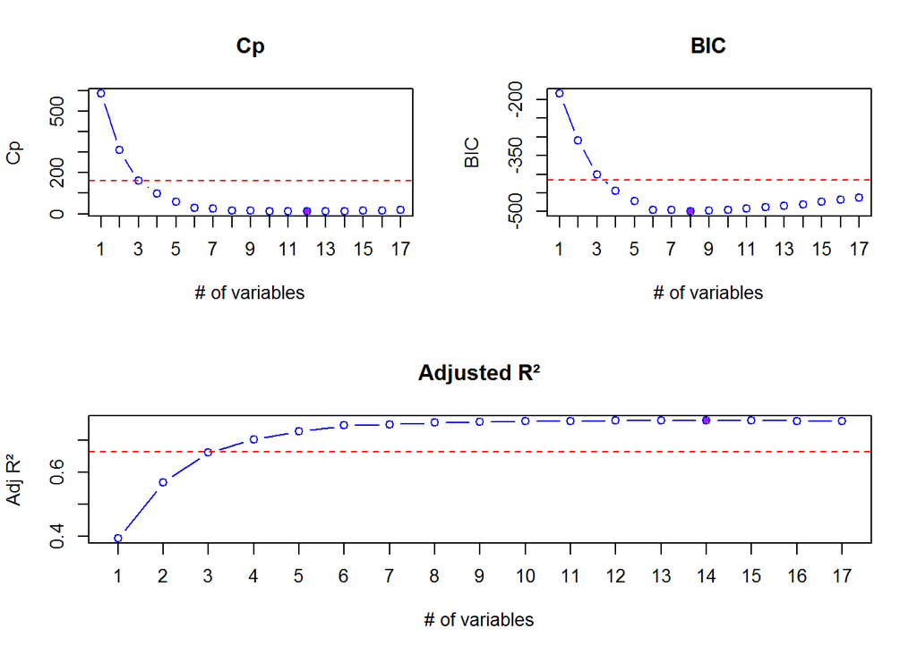

```r
# Plots
layout(matrix(c(1,2,3,3), 2, 2, byrow = TRUE))

plot(fselection.summary$cp ~ c(1:17), ylab = "Cp", xlab = "# of variables", col = "blue", type = "b", main = "Cp", xaxt = "n")
axis(1, xaxp=c(0, 17, 17))
points(which.min(fselection.summary$cp), fselection.summary$cp[which.min(fselection.summary$cp)], col = "purple", pch = 20)
abline(h = min(fselection.summary$cp) + sd(fselection.summary$cp), col="red", lty="dashed")

plot(fselection.summary$bic ~ c(1:17), ylab = "BIC", xlab = "# of variables", col = "blue", type = "b", main = "BIC", xaxt = "n")
axis(1, xaxp=c(0, 17, 17))
points(which.min(fselection.summary$bic), fselection.summary$bic[which.min(fselection.summary$bic)], col = "purple", pch = 20)
abline(h = min(fselection.summary$bic) + sd(fselection.summary$bic), col="red", lty="dashed")

plot(fselection.summary$adjr2 ~ c(1:17), ylab = "Adj R²", xlab = "# of variables", col = "blue", type = "b", main = "Adjusted R²", xaxt = "n")
axis(1, xaxp=c(0, 17, 17))
points(which.max(fselection.summary$adjr2), fselection.summary$adjr2[which.max(fselection.summary$adjr2)], col = "purple", pch = 20)
abline(h = max(fselection.summary$adjr2) - sd(fselection.summary$adjr2), col="red", lty="dashed")
```

We can see that the $C_p$, $BIC$ and $Adj-R^2$ points to different models as the better ones. Looking at the distance between the best fit in each of these statistics and their standard errors, the model with 4 variables seems to be a good choice: it is the simplest among those within 1 standard deviation from the model with the best fit on $C_p$, $BIC$ and $Adj-R^2$.  
These are the coefficients of the model with 4 variables and the intercept:

```r
coef(fselection, 4)
```

```
##   (Intercept)    PrivateYes      Terminal        Expend     Grad.Rate
## -3774.4992984  3882.6012073    73.9264042     0.2216084    51.7163596
```

**b)**

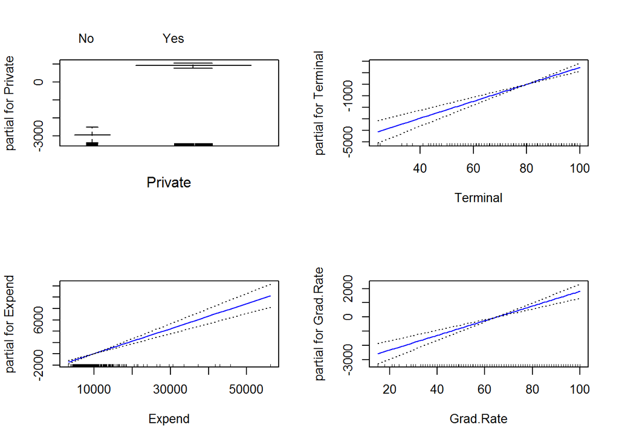

```r
fit = gam(Outstate ~ Private + Terminal + Expend + Grad.Rate, data = train)

par(mfrow = c(2,2))
plot(fit, se = TRUE, col = "blue")
```

Plot 1 displays a step function fit to the qualitative variable *Private*. The others display a linear fit of the remaining variables. These 4 plots show that these variables are related to increases in the response variable. A change from public to private universities implies a shift in outstate tuition from negative to positive. In the same way, a shift from the smallest values of Terminal, Expend and Grad.Rate to their respective biggest values implies increases in outstate tuition.

**c)**

```r
pred = predict(fit, test)
mean((test$Outstate - pred)^2)
```

```
## [1] 5456608
```

```r
sum((test$Outstate - pred)^2)/sum((test$Outstate - mean(train$Outstate))^2)
```

```
## [1] 0.3098557
```

The Mean Squared Error of this model when predicting Outstate on the test set is 5456608. Its Residual Sum of Squares is 30.99% the size of the RSS we would obtain if we had predicted Outstate using only its mean. This shows that the model improved a lot in comparisson to a naive base model. Although there is still room for improvements in this model.

**d)**

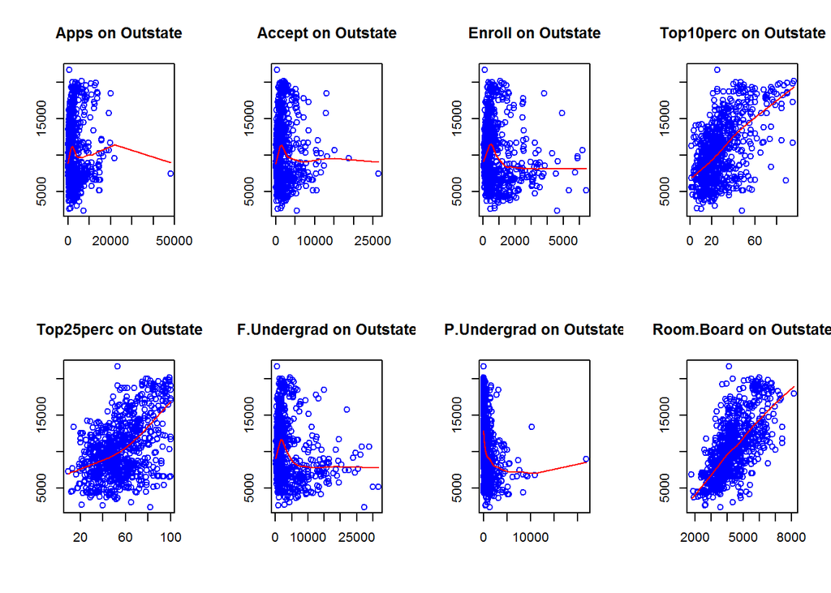

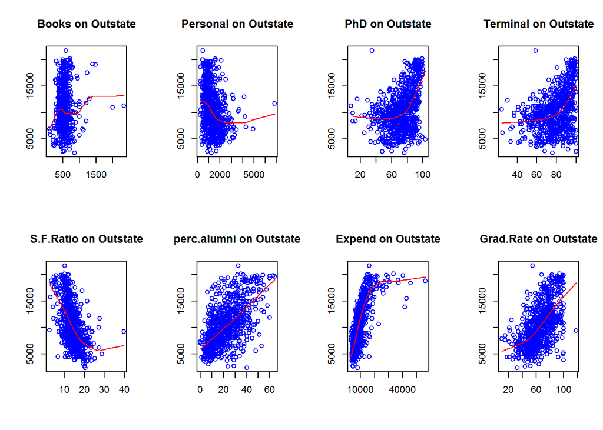

```r
par(mfrow = c(2,4))
for (i in 2:18){
  if(i != 9) {
    plot(College[,9] ~ College[,i], main = paste(names(College)[i],"on Outstate"), col = "blue", xlab = "", ylab = "")
    lines(lowess(College[,i], College[,9]), col = "red")
  }
}
```

The plots with the local regression line shows that some variables, such as *Personal, PHD, Terminal, S.F.Ratio, Expend and Grad.Rate*, could be included in non-linear models and those models, probably, would present improvements on the models tested in this exercise.

**11)** **a)**

```r
set.seed(1)
x1 = rnorm(100, 3, 2)
x2 = rnorm(100, -7, 4)
y = 0.7 + 3 * x1 - 5 * x2 + rnorm(100)
```

**b)**

```r
beta1 = 10
```

**c)**

```r
a = y - beta1 * x1
beta2 = lm(a~x2)$coef[2]
```

**d)**

```r
a = y - beta2 * x2
beta1 = lm(a~x1)$coef[2]
```

**e & f)**

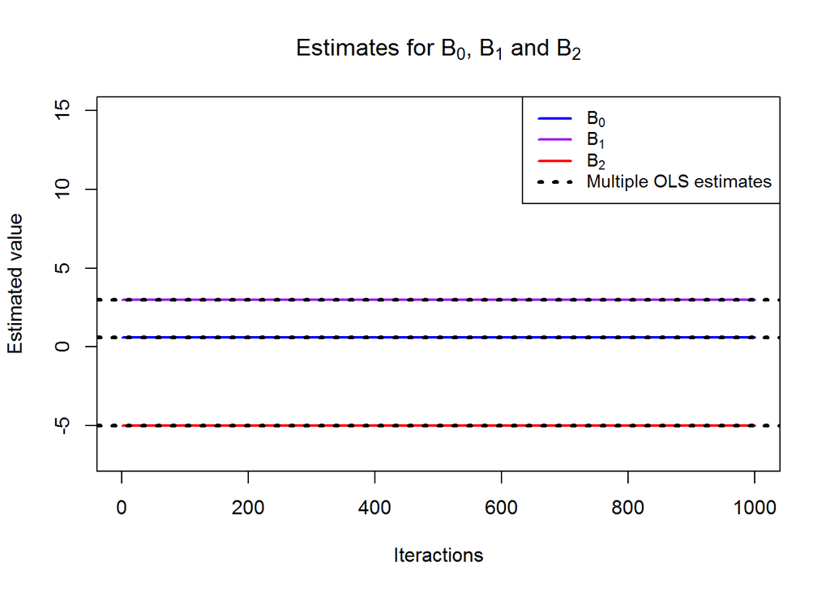

```r
b0 = c()
b1 = c()
b2 = c()
a = 0
for(i in 1:1000){
  a = y - beta1 * x1
  beta2 = lm(a~x2)$coef[2]
  a = y - beta2 * x2
  beta1 = lm(a~x1)$coef[2]
  b0[i] = lm(y ~ x1 + x2)$coef[1]
  b1[i] = beta1
  b2[i] = beta2
}
plot(1:1000, b0, xlab = "Iteractions", ylab = "Estimated value", type = "l", lwd = 2, ylim = c(-7, 15), col = "blue", main = expression("Estimates for B"[0]*", B"[1]*" and B"[2]))
lines(1:1000, b1, col = "purple", lwd = 2)
lines(1:1000, b2, col = "red", lwd = 2)

fit = lm(y ~ x1 + x2)
multib0 = coef(fit)[1]
multib1 = coef(fit)[2]
multib2 = coef(fit)[3]
abline(h = multib0, lty = 3, lwd = 3)
abline(h = multib1, lty = 3, lwd = 3)
abline(h = multib2, lty = 3, lwd = 3)

# Legend
legend("topright", c(expression("B"[0]), expression("B"[1]), expression("B"[2]), "Multiple OLS estimates"), lty = c(1,1,1,3), lwd = c(2,2,2,3), col = c("blue", "purple", "red", "black"), cex = 0.9)
```

The graph shows that the coefficients obtained for $B_0$, $B_1$ and $B_2$ through iteractions and through a multivariate regression are the same - We can also see that iteractive method generates coefficients that converge pretty quickly to the coefficients obtained in a multivariate linear model.

**g)** Since we were working with a linear model, a single iteration was enough to make the coefficients converge to the coefficients of a multiple regression.